# Palmer Penguins Modeling

Import the Palmer Penguins dataset and print out the first few rows.

Suppose we want to predict `bill_depth_mm` using the other variables in the dataset.

Which variables would we need to **dummify**?

```python
# Code Here
!pip install palmerpenguins
from palmerpenguins import load_penguins
import pandas as pd
import numpy as np
from sklearn.preprocessing import OneHotEncoder
```

```python
penguins = load_penguins()
penguins.head()
```

|  | species | island | bill_length_mm | bill_depth_mm | flipper_length_mm | body_mass_g | sex | year |
| --- | --- | --- | --- | --- | --- | --- | --- | --- |
| 0 | Adelie | Torgersen | 39.1 | 18.7 | 181.0 | 3750.0 | male | 2007 |
| 1 | Adelie | Torgersen | 39.5 | 17.4 | 186.0 | 3800.0 | female | 2007 |
| 2 | Adelie | Torgersen | 40.3 | 18.0 | 195.0 | 3250.0 | female | 2007 |
| 3 | Adelie | Torgersen | NaN | NaN | NaN | NaN | NaN | 2007 |
| 4 | Adelie | Torgersen | 36.7 | 19.3 | 193.0 | 3450.0 | female | 2007 |

```python
pd.get_dummies(penguins)
```

|  | bill_length_mm | bill_depth_mm | flipper_length_mm | body_mass_g | year | species_Adelie | species_Chinstrap | species_Gentoo | island_Biscoe | island_Dream | island_Torgersen | sex_female | sex_male |
| --- | --- | --- | --- | --- | --- | --- | --- | --- | --- | --- | --- | --- | --- |
| 0 | 39.1 | 18.7 | 181.0 | 3750.0 | 2007 | True | False | False | False | False | True | False | True |
| 1 | 39.5 | 17.4 | 186.0 | 3800.0 | 2007 | True | False | False | False | False | True | True | False |
| 2 | 40.3 | 18.0 | 195.0 | 3250.0 | 2007 | True | False | False | False | False | True | True | False |
| 3 | NaN | NaN | NaN | NaN | 2007 | True | False | False | False | False | True | False | False |
| 4 | 36.7 | 19.3 | 193.0 | 3450.0 | 2007 | True | False | False | False | False | True | True | False |
| ... | ... | ... | ... | ... | ... | ... | ... | ... | ... | ... | ... | ... | ... |
| 339 | 55.8 | 19.8 | 207.0 | 4000.0 | 2009 | False | True | False | False | True | False | False | True |
| 340 | 43.5 | 18.1 | 202.0 | 3400.0 | 2009 | False | True | False | False | True | False | True | False |
| 341 | 49.6 | 18.2 | 193.0 | 3775.0 | 2009 | False | True | False | False | True | False | False | True |
| 342 | 50.8 | 19.0 | 210.0 | 4100.0 | 2009 | False | True | False | False | True | False | False | True |
| 343 | 50.2 | 18.7 | 198.0 | 3775.0 | 2009 | False | True | False | False | True | False | True | False |

344 rows × 13 columns

Dummify species, island, and sex

Let’s use `bill_length_mm` to predict `bill_depth_mm`. Prepare your data and fit the following models on the entire dataset:

- Simple linear regression (e.g. straight-line) model
- Quadratic (degree 2 polynomial) model
- Cubic (degree 3 polynomial) model
- Degree 10 polynomial model

Make predictions for each model and plot your fitted models on the scatterplot.

```python
from sklearn.linear_model import LinearRegression

penguins_clean = penguins.dropna(subset=["bill_length_mm", "bill_depth_mm"])

model1 = LinearRegression()
model1.fit(
    X=penguins_clean[["bill_length_mm"]],
    y=penguins_clean["bill_depth_mm"]
    )
```

```
LinearRegression()
```

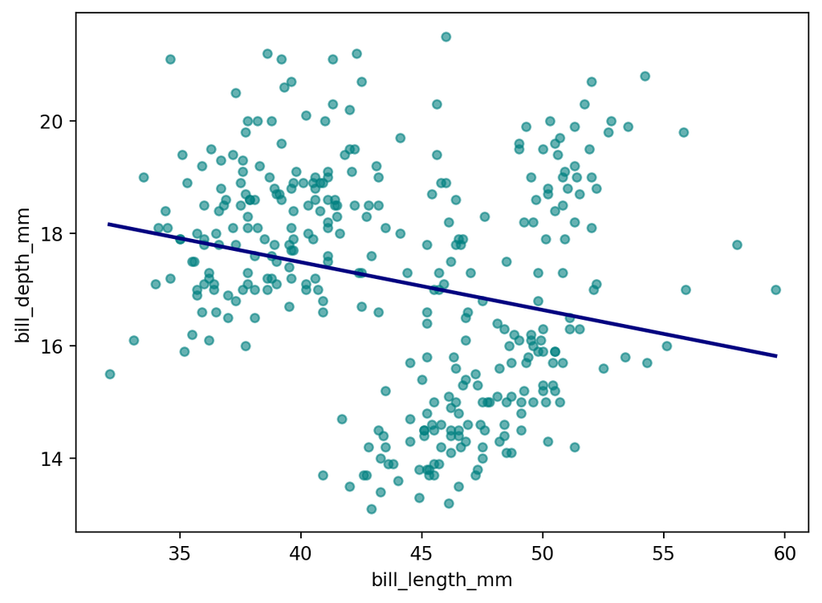

```python
X_new = pd.DataFrame()
X_new["bill_length_mm"] = np.linspace(
    penguins_clean["bill_length_mm"].min(),
    penguins_clean["bill_length_mm"].max(),
    num=1000
)

y_new_ = pd.Series(
    model1.predict(X_new),
    index=X_new["bill_length_mm"]
)

penguins_clean.plot.scatter(x="bill_length_mm", y="bill_depth_mm", color="teal", alpha=0.6)

y_new_.plot.line(c="navy", linewidth=2)
```

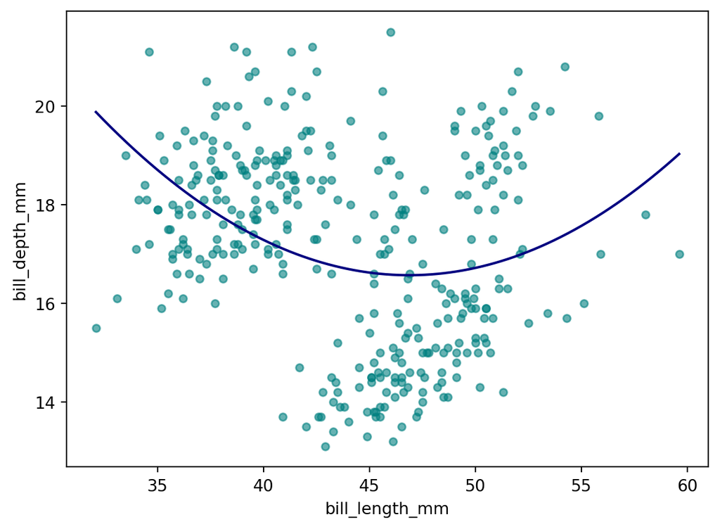

```python
penguins_clean["bill_length_mm_square"] = penguins_clean["bill_length_mm"] ** 2

square_model = LinearRegression()
square_model.fit(
    X=penguins_clean[["bill_length_mm", "bill_length_mm_square"]],
    y=penguins_clean["bill_depth_mm"]
)

square_model.coef_, square_model.intercept_

X_new = pd.DataFrame()
X_new["bill_length_mm"] = np.linspace(
    penguins_clean["bill_length_mm"].min(),
    penguins_clean["bill_length_mm"].max(),
    num=1000)
X_new["bill_length_mm_square"] = X_new["bill_length_mm"] ** 2

y_new_ = pd.Series(
    square_model.predict(X_new),
    index=X_new["bill_length_mm"])

penguins_clean.plot.scatter(x="bill_length_mm", y="bill_depth_mm", color="teal", alpha=0.6)
y_new_.plot.line(c="navy")
```